# Predicting Grain Crop Yields in India for Years 1997 - 2020

Team BCG: Cameron Greenwalt, Mark Bauer, Ben Carman

2023-07-31

## Libariries and Functions

Below are some libraries and helper functions we utilize

```r
library(tidyverse)
library(knitr)
library(plyr)
library(glmnet)
library(MASS)
library(MASSExtra)
library(car)
library(lmtest)
library(coefplot)
library(rlist)
```

```r
plot_fitted_resid <- function(model, pointcol = "dodgerblue", linecol = "darkorange") {
  plot(fitted(model), resid(model),
    col = pointcol, pch = 20, cex = 1.5,
    xlab = "Fitted", ylab = "Residuals", main = "Fitted vs. Residuals"
  )
  abline(h = 0, col = linecol, lwd = 2)
}

plot_qq <- function(model, pointcol = "dodgerblue", linecol = "darkorange") {
  qqnorm(resid(model), col = pointcol, pch = 20, cex = 1.5)
  qqline(resid(model), col = linecol, lwd = 2)
}

plot_fitted_v_actual <- function(model, pointcol = "dodgerblue", linecol = "darkorange") {
  set_plot_grid(1, 1)
  plot(fitted(model), resid(model) + fitted(model),
    col = pointcol, pch = 20, cex = 1.5,
    xlab = "Fitted", ylab = "Actual", main = "Fitted vs. Actual"
  )
  lines(x = fitted(model), y = fitted(model), col = linecol, lwd = 2)
}

set_plot_grid <- function(nrow = 1, ncol = 1) {
  par(mfrow = c(nrow, ncol))
}

assumptions_plots <- function(model) {
  set_plot_grid(1, 3)
  plot_fitted_resid(model)
  plot_qq(model)
  hist(resid(model), main = "Histogram of Model Residuals", xlab = "Residuals")
}

plot_cooksd <- function(model) {
  set_plot_grid(1, 1)
  cooksd <- cooks.distance(model)
  n <- length(model$residuals)
  infl <- cooksd > (4 / n)
  plot(1:n,
    cooksd,
    col = ifelse(infl == 1, "red", "black"),
    xlab = "Sample Index",
    ylab = "Cook's Distance",
    main = "Cook's Distances"
  )
  abline(
    h = 4 / n,
    col = "royalblue"
  )
}

bc_transform <- function(x, lambda) {
  # ((x)^lambda - 1) / lambda
  MASSExtra::bc(x, lambda)
}

get_loocv_rmse <- function(model) {
  sqrt(mean((resid(model) / (1 - hatvalues(model)))^2))
}

get_adj_r2 <- function(model) {
  summary(model)$adj.r.squared
}

idx_infl_pts <- function(model) {
  cooks.distance(model) > (4 / length(resid(model)))
}

output_diagnostics <- function(model, vif = TRUE) {
  if (length(coef(model)) < 30) {
    print("Model Summary:")
    print(summary(model))
  }
  plot_fitted_v_actual(model)
  assumptions_plots(model)
  plot_cooksd(model)
  bptest(model)
  shapiro.test(resid(model))

  print(c("LOOCV-RMSE:", get_loocv_rmse(model)))

  if (vif) {
    car::vif(model)
  }
}

inverse_bc_transform <- function(x, lambda) {
  # ((x*lambda)+1)^(1/lambda)
  bc_inv(x, lambda)
}
```

## Introduction

In this project we will explore our ability to predict the amount of production of grain crops in India based on some information about the land in which they were grown on (field size, general region), the type of grain, inputs used (fertilizer, pesticide), and weather (season, rain).

Below we provide a summary or the data. The source for the data can be found (here)[https://www.kaggle.com/datasets/akshatgupta7/crop-yield-in-indian-states-dataset].

Response - Production: The quantity of crop production (in metric tons).

Predictors

- Crop: The name of the cultivated crop .
- Crop_Year: The year in which the crop was grown.
- Season: The specific cropping season (e.g., Kharif, Rabi, Whole Year).
- State: The Indian state where the crop was cultivated.
- Area: The total land area (in hectares) under cultivation for the specific crop.
- Annual_Rainfall: The annual rainfall received in the crop-growing region (in mm).
- Fertilizer: The total amount of fertilizer used for the crop (in kilograms).
- Pesticide: The total amount of pesticide used for the crop (in kilograms).

## Methods

### Data import, exploration, and cleaning

```r
crops <- read_csv("crop_yield.csv")
```

```r
crops <- crops[, !(names(crops) %in% c("Yield"))]
```

In order to limit scope, we also limit the types of crops under observation to a subset of grains (e.g., wheat, barley, rye, etc.). We also convert categorical variables to factor variables as appropriate.

```r
grains <- c(
  "Amaranth", "Barley", "Bulgur", "Corn", "Farro", "Einkorn", "Emmer",
  "Spelt", "Millet", "Freaked", "Farik", "Durum Wheat",
  "Khorasan Wheat", "Oats", "Quinoa", "Kana", "Rice", "Rye",
  "Sorghum", "Teff", "Triticale", "Wheat", "Wild Rice", "Wheat",
  "Wheat berries", "Hominy", "Spelt", "Rye", "Brown Rice", "Farro",
  "Emmer", "Barley", "Bran", "Durum Wheat ", "Triticale",
  "Bulgur Wheat", "Couscous", "Farina", "Kamut", "Orzo", "Semolina",
  "Graham", "Oats", "Corn", "maize", "Cornflour ", "Cornmeal", "Rice",
  "Wild Rice", "Teff", "Montina flour", "Sorghum", "Oats", "Freekeh",
  "Emmer", "Eikorn", "Malt", "Graham", "Couscous", "Polenta", "Muesli",
  "Seitan", "Panko", "Grain Alcohol", "Atta Flour", "Amaranth", "Quinoa",
  "Millet", "Barley Malt", "Beer", "Bleached Flour", "Breads",
  "Baked Goods", "Brown Rice Syrup", "Buckwheat", "Corn Flakes",
  "Croutons", "Cereals", "Wheat Germ", "Enriched Bleach Flour",
  "Malted Barley Flour", "Millet", "Granary Flour", "Groats",
  "Pastas", "Matzo", "Rice Milk", "Seitan", "Tabbouleh", "Udon",
  "Corn Starch", "Wheat nuts", "Other Cereals"
)

# Drop non-grain rows
crops <- crops[str_squish(tolower(crops$Crop)) %in% str_squish(tolower(grains)), ]

# Convert categorical variables to factor variables
crops$Crop <- as.factor(crops$Crop)
crops$Season <- as.factor(crops$Season)
crops$State <- as.factor(crops$State)

levels(crops$Crop)
```

```
## [1] "Barley"        "Maize"         "Other Cereals" "Rice"
## [5] "Wheat"
```

Here we present a few rows from the cleaned and pared down dataset:

```r
kable(
  head(crops, 5)
)
```

| Crop | Crop_Year | Season | State | Area | Production | Annual_Rainfall | Fertilizer | Pesticide |
| --- | --- | --- | --- | --- | --- | --- | --- | --- |
| Maize | 1997 | Kharif | Assam | 19216 | 14721 | 2051.4 | 1828787 | 5956.96 |
| Rice | 1997 | Autumn | Assam | 607358 | 398311 | 2051.4 | 57802261 | 188280.98 |
| Rice | 1997 | Summer | Assam | 174974 | 209623 | 2051.4 | 16652276 | 54241.94 |
| Rice | 1997 | Winter | Assam | 1743321 | 1647296 | 2051.4 | 165911860 | 540429.51 |
| Wheat | 1997 | Rabi | Assam | 84698 | 110054 | 2051.4 | 8060709 | 26256.38 |

As we prepare the dataset for modeling, we also explore the remaining factor variables:

```r
levels(crops$Season)
```

```
## [1] "Autumn"     "Kharif"     "Rabi"       "Summer"     "Whole Year"
## [6] "Winter"
```

The season column appears reasonable. Let’s also check the values for State:

```r
levels(crops$State)
```

```
##  [1] "Andhra Pradesh"    "Arunachal Pradesh" "Assam"
##  [4] "Bihar"             "Chhattisgarh"      "Delhi"
##  [7] "Goa"               "Gujarat"           "Haryana"
## [10] "Himachal Pradesh"  "Jammu and Kashmir" "Jharkhand"
## [13] "Karnataka"         "Kerala"            "Madhya Pradesh"
## [16] "Maharashtra"       "Manipur"           "Meghalaya"
## [19] "Mizoram"           "Nagaland"          "Odisha"
## [22] "Puducherry"        "Punjab"            "Sikkim"
## [25] "Tamil Nadu"        "Telangana"         "Tripura"
## [28] "Uttar Pradesh"     "Uttarakhand"       "West Bengal"
```

In order to keep our model’s complexity minimal, we will pre-process the data to consider zones in India instead of working at the granularity of individual states:

```r
# See https://en.wikipedia.org/wiki/Administrative_divisions_of_India

states_to_zones <- c(
  "Chandigarh" = "Northern",
  "Delhi" = "Northern",
  "Haryana" = "Northern",
  "Himachal Pradesh" = "Northern",
  "Jammu and Kashmir" = "Northern",
  "Ladakh" = "Northern",
  "Punjab" = "Northern",
  "Rajasthan" = "Northern",
  "Assam" = "North Eastern",
  "Arunachal Pradesh" = "North Eastern",
  "Manipur" = "North Eastern",
  "Meghalaya" = "North Eastern",
  "Mizoram" = "North Eastern",
  "Nagaland" = "North Eastern",
  "Tripura" = "North Eastern",
  "Sikkim" = "North Eastern",
  "Chhattisgarh" = "Central",
  "Madhya Pradesh" = "Central",
  "Uttarakhand" = "Central",
  "Uttar Pradesh" = "Central",
  "Bihar" = "Eastern",
  "Jharkhand" = "Eastern",
  "Odisha" = "Eastern",
  "West Bengal" = "Eastern",
  "Goa" = "Western",
  "Gujarat" = "Western",
  "Maharashtra" = "Western",
  "Andhra Pradesh" = "Southern",
  "Karnataka" = "Southern",
  "Kerala" = "Southern",
  "Puducherry" = "Southern",
  "Tamil Nadu" = "Southern",
  "Telangana" = "Southern"
)


crops$State <- revalue(crops$State, states_to_zones)
names(crops)[which(names(crops) == "State")] <- "Zone"
crops$Zone <- as.factor(crops$Zone)
levels(crops$Zone)
```

```
## [1] "Southern"      "North Eastern" "Eastern"       "Central"
## [5] "Northern"      "Western"
```

```r
# Train-test split
set.seed(0)

sample <- sample(c(TRUE, FALSE), nrow(crops), replace = TRUE, prob = c(0.8, 0.2))
crops.train <- crops[sample, ]
crops.test.cropyear_cont <- crops[!sample, ]

nrow(crops)
```

```
## [1] 3160
```

```r
nrow(crops.train)
```

```
## [1] 2522
```

```r
nrow(crops.test.cropyear_cont)
```

```
## [1] 638
```

As we examined the data and discussed, something interesting we wanted to test/investigate is the concept of crop year as a categorical versus a continuous variable. For our initial try, we utilize it as continuous.

```r
vars.res <- "Production"
vars.con <- c("Area", "Annual_Rainfall", "Fertilizer", "Pesticide", "Crop_Year")
vars.cat <- c("Crop", "Season", "Zone")
```

We then do a quick examination of the pairs plot.

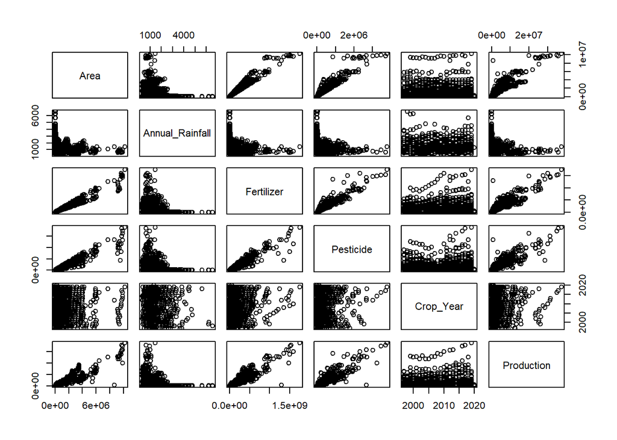

```r
pairs(crops.train[, c(vars.con, vars.res)])
```

For our first model, we chose a baseline additive model with all predictors.

```r
baseline.cropyear_cont <- lm(Production ~ ., data = crops.train)
output_diagnostics(baseline.cropyear_cont)
```

```
## [1] "Model Summary:"
##
## Call:
## lm(formula = Production ~ ., data = crops.train)
##
## Residuals:
##       Min        1Q    Median        3Q       Max
## -24053173   -337021     20621    336170   6719671
##
## Coefficients:
##                     Estimate Std. Error t value Pr(>|t|)
## (Intercept)       -7.325e+06  7.408e+06  -0.989 0.322882
## CropMaize          3.126e+05  9.554e+04   3.272 0.001083 **
## CropOther Cereals  2.774e+05  1.329e+05   2.087 0.036993 *
## CropRice          -2.972e+04  1.018e+05  -0.292 0.770382
## CropWheat          2.902e+05  9.553e+04   3.037 0.002410 **
## Crop_Year          3.683e+03  3.684e+03   1.000 0.317462
## SeasonKharif      -2.961e+05  1.037e+05  -2.856 0.004331 **
## SeasonRabi         1.706e+05  1.113e+05   1.532 0.125628
## SeasonSummer       2.567e+05  1.086e+05   2.364 0.018153 *
## SeasonWhole Year  -4.292e+05  2.498e+05  -1.718 0.085919 .
## SeasonWinter      -9.610e+05  1.294e+05  -7.428 1.51e-13 ***
## ZoneNorth Eastern -2.763e+05  8.056e+04  -3.430 0.000613 ***
## ZoneEastern       -6.570e+05  8.310e+04  -7.906 3.93e-15 ***
## ZoneCentral       -8.428e+05  8.408e+04 -10.024  < 2e-16 ***
## ZoneNorthern       4.142e+05  8.688e+04   4.767 1.98e-06 ***
## ZoneWestern       -5.737e+05  8.890e+04  -6.453 1.31e-10 ***
## Area               1.264e+00  9.865e-02  12.814  < 2e-16 ***
## Annual_Rainfall    2.417e+01  3.602e+01   0.671 0.502292
## Fertilizer         8.774e-03  6.916e-04  12.686  < 2e-16 ***
## Pesticide          1.086e+00  2.426e-01   4.478 7.87e-06 ***
## ---
## Signif. codes:  0 '***' 0.001 '**' 0.01 '*' 0.05 '.' 0.1 ' ' 1
##
## Residual standard error: 1111000 on 2502 degrees of freedom
## Multiple R-squared:  0.9027, Adjusted R-squared:  0.902
## F-statistic:  1222 on 19 and 2502 DF,  p-value: < 2.2e-16
```

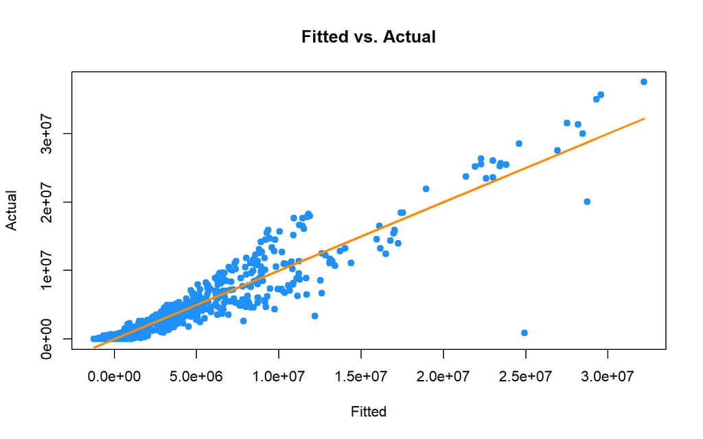

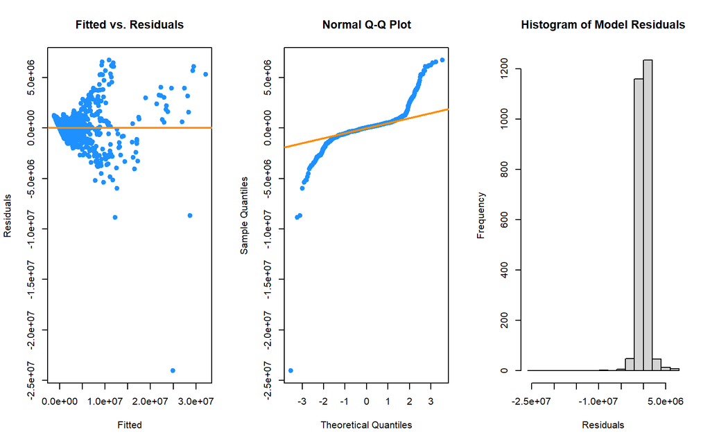

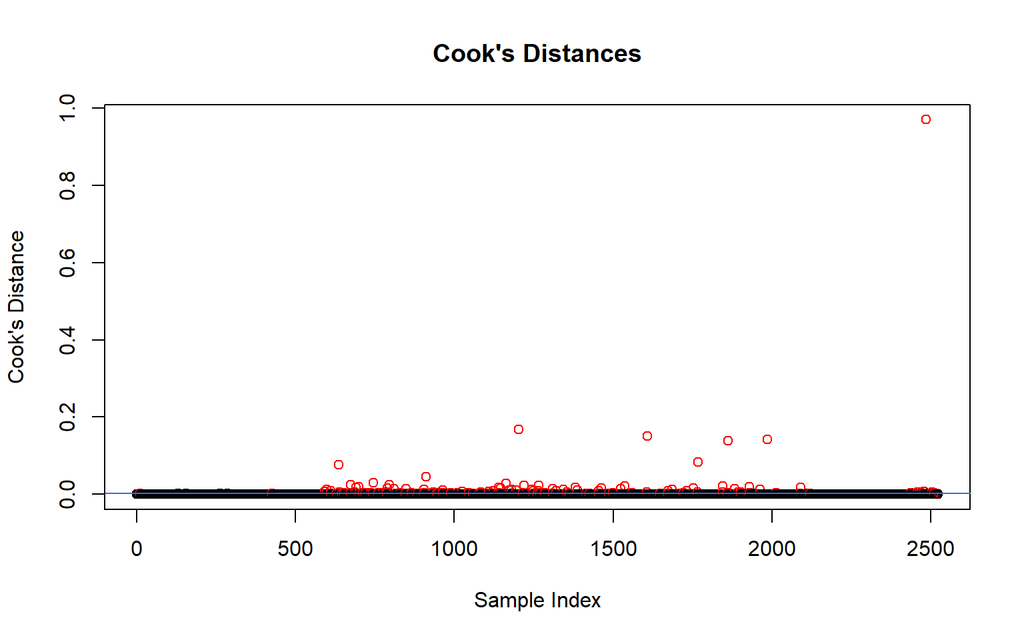

```
## [1] "LOOCV-RMSE:"      "1131425.68559399"
```

```
##                      GVIF Df GVIF^(1/(2*Df))
## Crop             3.136035  4        1.153580
## Crop_Year        1.188466  1        1.090168
## Season           3.550211  5        1.135077
## Zone             3.419092  5        1.130814
## Area            31.916345  1        5.649455
## Annual_Rainfall  1.899723  1        1.378304
## Fertilizer      29.295112  1        5.412496
## Pesticide       15.154892  1        3.892929
```

We have one influential point we chose to remove. While we are not completely confident in our justification for this, we are prioritizing simplicity over rigor in both this removal, and in other instances of high influential points that are found.

```r
idx_remove <- which.max(cooks.distance(baseline.cropyear_cont))
crops.train.no_infl <- crops.train[-idx_remove, ]

baseline.no_infl.cropyear_cont <- lm(Production ~ ., data = crops.train.no_infl)
output_diagnostics(baseline.no_infl.cropyear_cont)
```

```
## [1] "Model Summary:"
##
## Call:
## lm(formula = Production ~ ., data = crops.train.no_infl)
##
## Residuals:
##      Min       1Q   Median       3Q      Max
## -9545724  -345755    12646   325819  6523620
##
## Coefficients:
##                     Estimate Std. Error t value Pr(>|t|)
## (Intercept)       -3.827e+06  6.650e+06  -0.575 0.565030
## CropMaize          2.898e+05  8.575e+04   3.380 0.000736 ***
## CropOther Cereals  2.993e+05  1.193e+05   2.509 0.012181 *
## CropRice          -7.556e+04  9.138e+04  -0.827 0.408390
## CropWheat          1.931e+05  8.583e+04   2.250 0.024532 *
## Crop_Year          1.920e+03  3.307e+03   0.581 0.561618
## SeasonKharif      -2.933e+05  9.306e+04  -3.151 0.001645 **
## SeasonRabi         1.967e+05  9.993e+04   1.969 0.049115 *
## SeasonSummer       3.754e+05  9.756e+04   3.848 0.000122 ***
## SeasonWhole Year  -4.130e+05  2.242e+05  -1.842 0.065573 .
## SeasonWinter      -1.067e+06  1.162e+05  -9.178  < 2e-16 ***
## ZoneNorth Eastern -2.576e+05  7.230e+04  -3.562 0.000375 ***
## ZoneEastern       -6.163e+05  7.460e+04  -8.262 2.30e-16 ***
## ZoneCentral       -9.115e+05  7.551e+04 -12.071  < 2e-16 ***
## ZoneNorthern       4.266e+05  7.798e+04   5.470 4.94e-08 ***
## ZoneWestern       -5.884e+05  7.979e+04  -7.375 2.23e-13 ***
## Area               1.135e+00  8.869e-02  12.799  < 2e-16 ***
## Annual_Rainfall    4.572e+01  3.234e+01   1.414 0.157584
## Fertilizer         9.778e-03  6.221e-04  15.718  < 2e-16 ***
## Pesticide          1.337e+00  2.179e-01   6.134 9.96e-10 ***
## ---
## Signif. codes:  0 '***' 0.001 '**' 0.01 '*' 0.05 '.' 0.1 ' ' 1
##
## Residual standard error: 997000 on 2501 degrees of freedom
## Multiple R-squared:  0.9217, Adjusted R-squared:  0.9211
## F-statistic:  1549 on 19 and 2501 DF,  p-value: < 2.2e-16
```

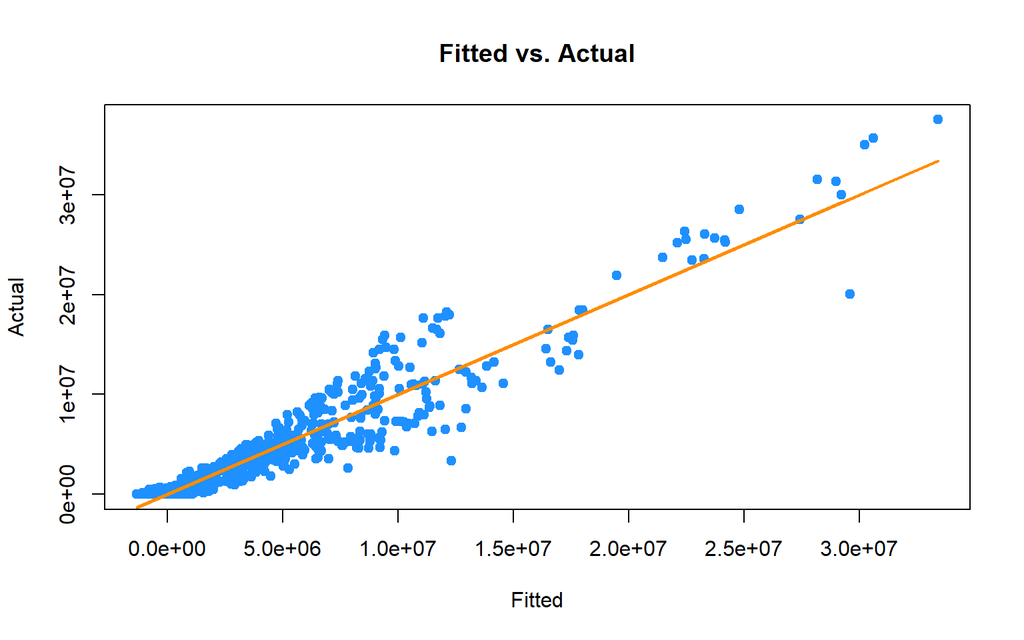

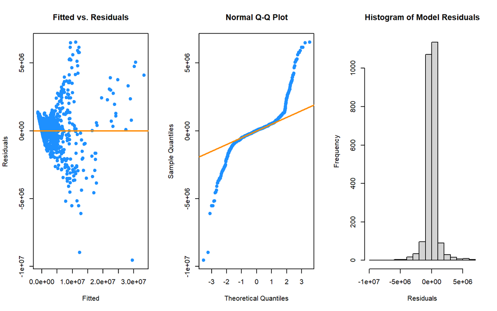

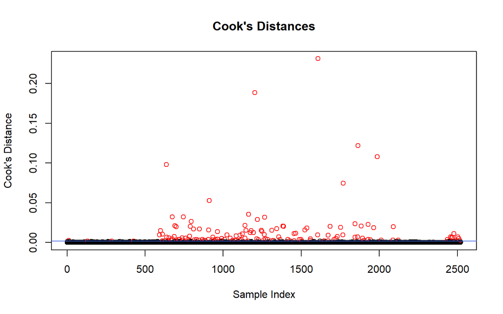

```
## [1] "LOOCV-RMSE:"      "1010602.16663902"
```

```
##                      GVIF Df GVIF^(1/(2*Df))
## Crop             3.144020  4        1.153946
## Crop_Year        1.188922  1        1.090377
## Season           3.569879  5        1.135704
## Zone             3.426192  5        1.131048
## Area            31.512060  1        5.613560
## Annual_Rainfall  1.901113  1        1.378809
## Fertilizer      28.835434  1        5.369863
## Pesticide       14.883293  1        3.857887
```

Our diagnostics gave us reason for concern with regard to our LINE assumptions, so we perform a Box-Cox transformation.

```r
# See https://www.statology.org/box-cox-transformation-in-r/

# Define plotting area
set_plot_grid(1, 2)

# Box-cox requires that the response be positive (0 doesn't work), so we add
# 1 here (just need to remember to subtract 1 when giving actual predictions)
crops$Production <- crops$Production + 1
crops.train$Production <- crops.train$Production + 1
crops.test.cropyear_cont$Production <- crops.test.cropyear_cont$Production + 1
crops.train.no_infl$Production <- crops.train.no_infl$Production + 1

baseline.cropyear_cont <- lm(I(Production) ~ ., data = crops.train.no_infl)

bc <- boxcox(baseline.cropyear_cont)
(baseline.bc.cropyear_cont_lambda <- bc$x[which.max(bc$y)])
```

```
## [1] 0.2222222
```

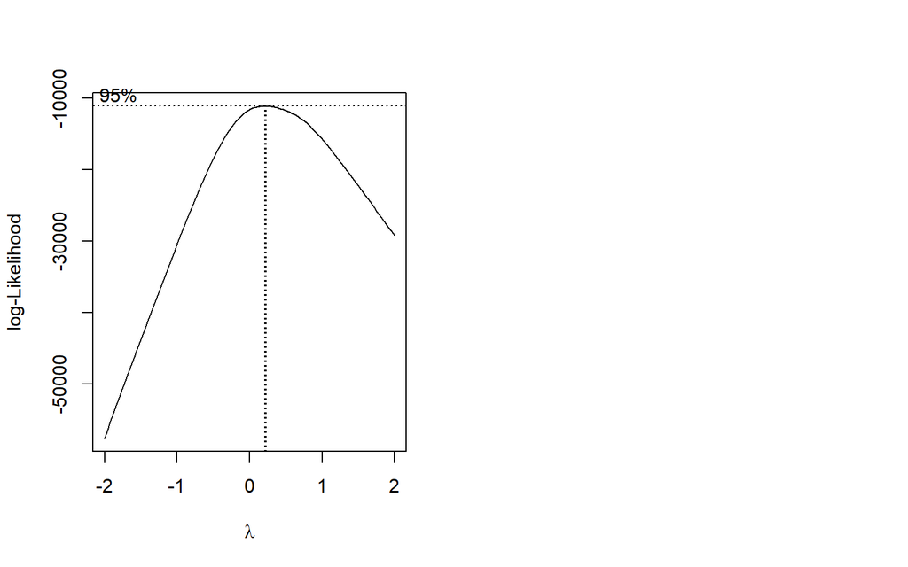

```
## [1] "Model Summary:"
##
## Call:
## lm(formula = bc_transform(Production, baseline.bc.cropyear_cont_lambda) ~
##     ., data = crops.train.no_infl)
##
## Residuals:
##     Min      1Q  Median      3Q     Max
## -95.048 -13.281   1.029  14.972  51.721
##
## Coefficients:
##                     Estimate Std. Error t value Pr(>|t|)
## (Intercept)       -1.094e+02  1.417e+02  -0.772  0.44008
## CropMaize          2.062e+01  1.827e+00  11.285  < 2e-16 ***
## CropOther Cereals -1.462e+01  2.542e+00  -5.753 9.82e-09 ***
## CropRice           3.370e+01  1.947e+00  17.311  < 2e-16 ***
## CropWheat          2.057e+01  1.828e+00  11.247  < 2e-16 ***
## Crop_Year          7.762e-02  7.044e-02   1.102  0.27061
## SeasonKharif       5.669e+00  1.982e+00   2.860  0.00428 **
## SeasonRabi         2.041e+00  2.129e+00   0.959  0.33787
## SeasonSummer      -8.670e+00  2.078e+00  -4.172 3.13e-05 ***
## SeasonWhole Year  -1.459e+01  4.776e+00  -3.054  0.00228 **
## SeasonWinter       8.600e-01  2.475e+00   0.347  0.72829
## ZoneNorth Eastern -1.893e+01  1.540e+00 -12.292  < 2e-16 ***
## ZoneEastern        2.285e-01  1.589e+00   0.144  0.88566
## ZoneCentral       -1.197e+01  1.609e+00  -7.442 1.36e-13 ***
## ZoneNorthern      -7.237e+00  1.661e+00  -4.357 1.37e-05 ***
## ZoneWestern       -1.671e-01  1.700e+00  -0.098  0.92169
## Area               1.569e-05  1.889e-06   8.306  < 2e-16 ***
## Annual_Rainfall   -5.946e-03  6.889e-04  -8.631  < 2e-16 ***
## Fertilizer         3.634e-08  1.325e-08   2.742  0.00615 **
## Pesticide          5.198e-06  4.643e-06   1.120  0.26297
## ---
## Signif. codes:  0 '***' 0.001 '**' 0.01 '*' 0.05 '.' 0.1 ' ' 1
##
## Residual standard error: 21.24 on 2501 degrees of freedom
## Multiple R-squared:  0.7401, Adjusted R-squared:  0.7381
## F-statistic: 374.8 on 19 and 2501 DF,  p-value: < 2.2e-16
```

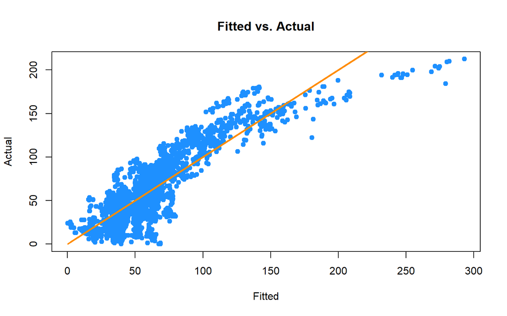

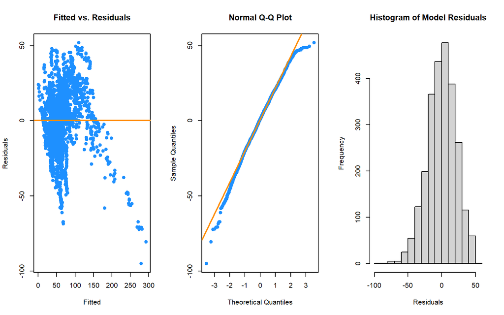

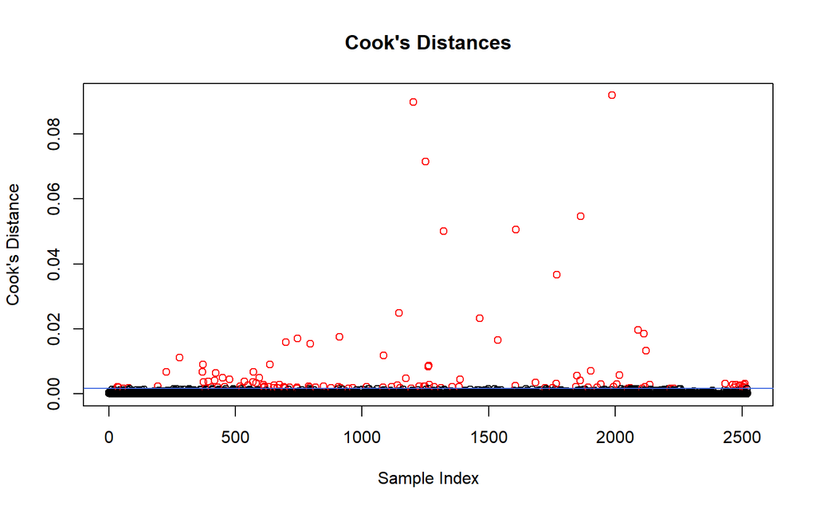

```
## [1] "LOOCV-RMSE:"      "21.4152945592002"
```

```
##                      GVIF Df GVIF^(1/(2*Df))
## Crop             3.144020  4        1.153946
## Crop_Year        1.188922  1        1.090377
## Season           3.569879  5        1.135704
## Zone             3.426192  5        1.131048
## Area            31.512060  1        5.613560
## Annual_Rainfall  1.901113  1        1.378809
## Fertilizer      28.835434  1        5.369863
## Pesticide       14.883293  1        3.857887
```

```r
baseline.bc.cropyear_cont <- lm(bc_transform(Production, baseline.bc.cropyear_cont_lambda) ~ ., data = crops.train.no_infl)
output_diagnostics(baseline.bc.cropyear_cont)
```

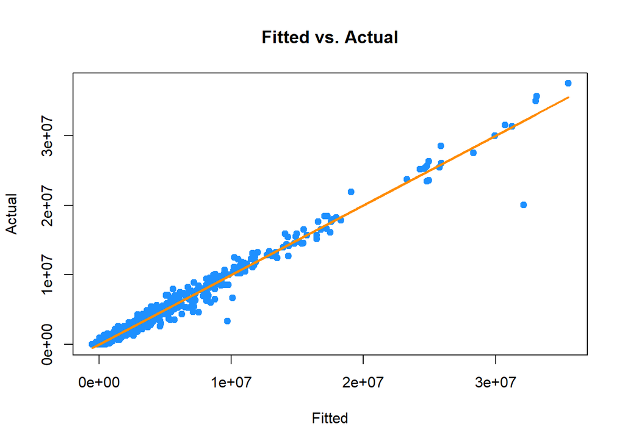

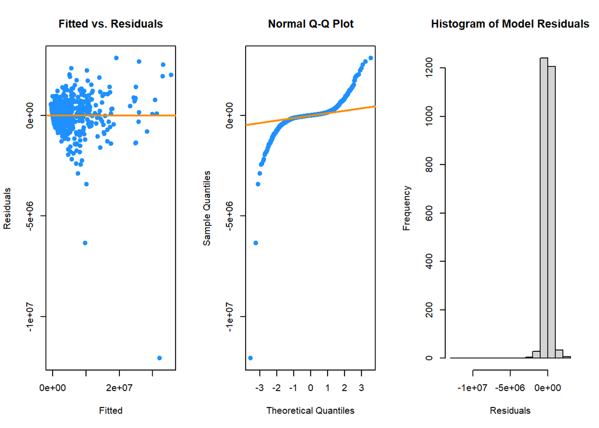

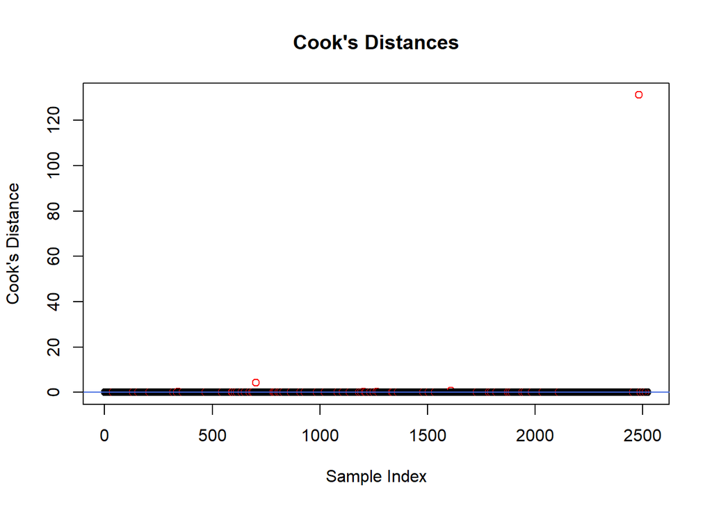

```
## [1] "LOOCV-RMSE:"     "1495664.8420122"
```

```r
# continuous-categorical interactions
baseline.poly.form.cropyear_cont <- as.formula(Production ~
  (poly(Area, degree = 2, raw = 1) +
    poly(Annual_Rainfall, degree = 2, raw = 1) +
    poly(Fertilizer, degree = 2, raw = 1) +
    poly(Pesticide, degree = 2, raw = 1) +
    poly(Crop_Year, degree = 2, raw = 1)) *
    (Crop + Season + Zone))
baseline.poly.cropyear_cont <- lm(baseline.poly.form.cropyear_cont, data = crops.train)
output_diagnostics(baseline.poly.cropyear_cont, vif = 0)
```

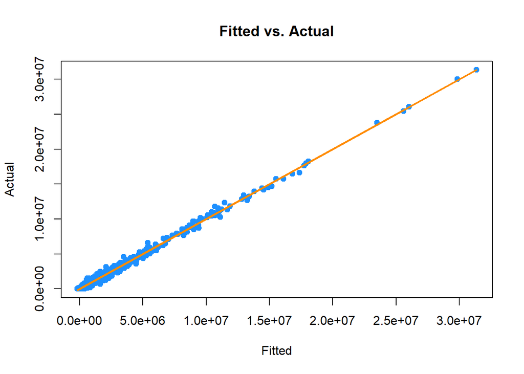

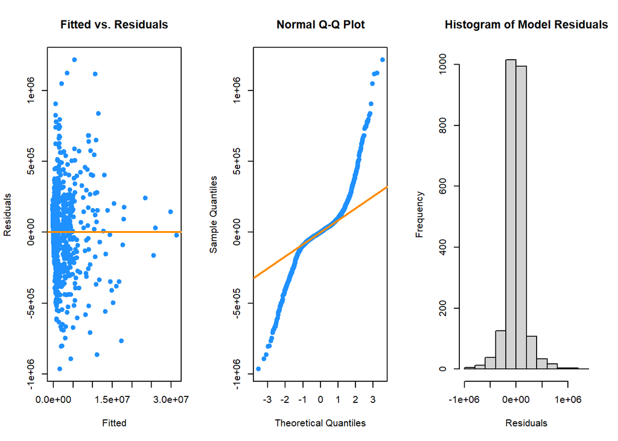

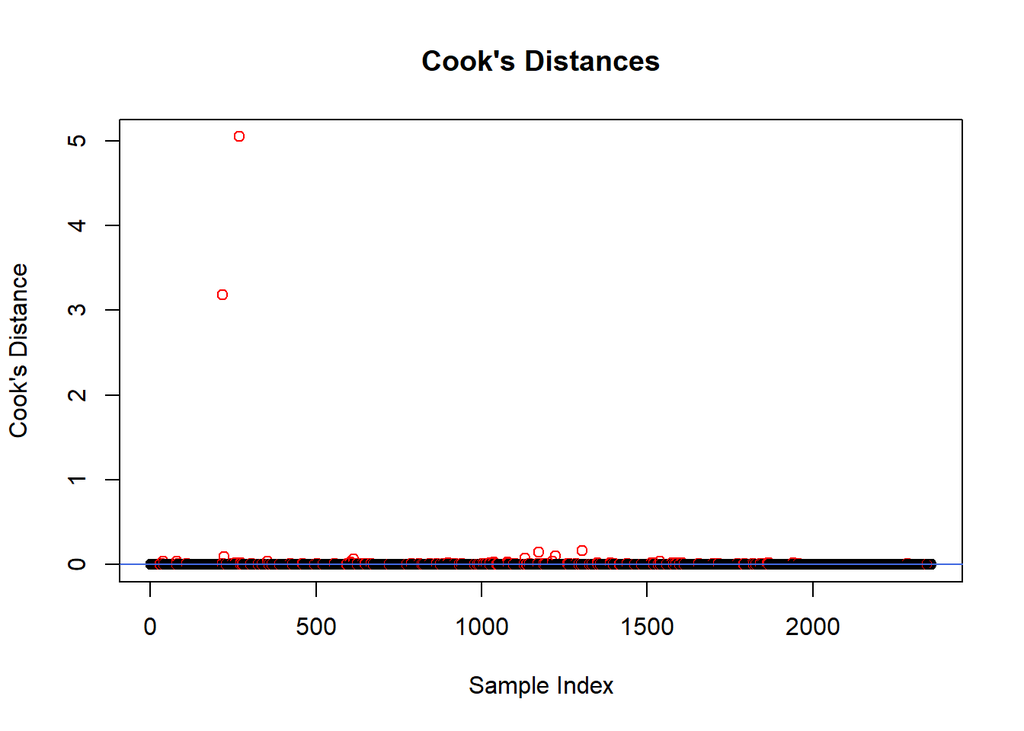

```
## [1] "LOOCV-RMSE:"      "242967.187091434"
```

```r
crops.train.poly.no_infl <- crops.train[!idx_infl_pts(baseline.poly.cropyear_cont), ]

baseline.poly.cropyear_cont <- lm(baseline.poly.form.cropyear_cont, data = crops.train.poly.no_infl)
output_diagnostics(baseline.poly.cropyear_cont, vif = 0)
```

```r
bc <- boxcox(baseline.poly.cropyear_cont)
```

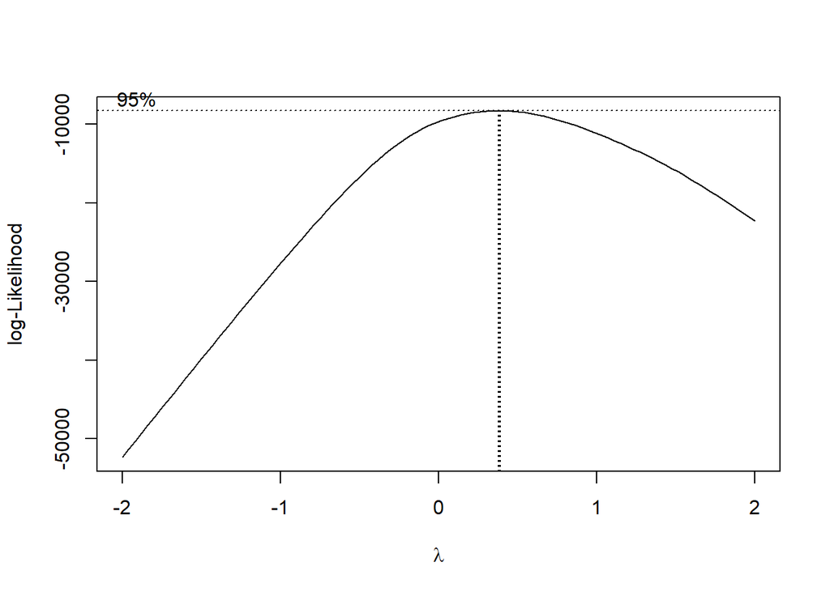

```r
(baseline.poly.bc.cropyear_cont_lambda <- bc$x[which.max(bc$y)])
```

```
## [1] 0.3838384
```

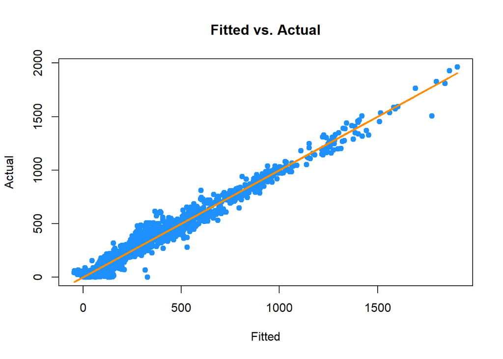

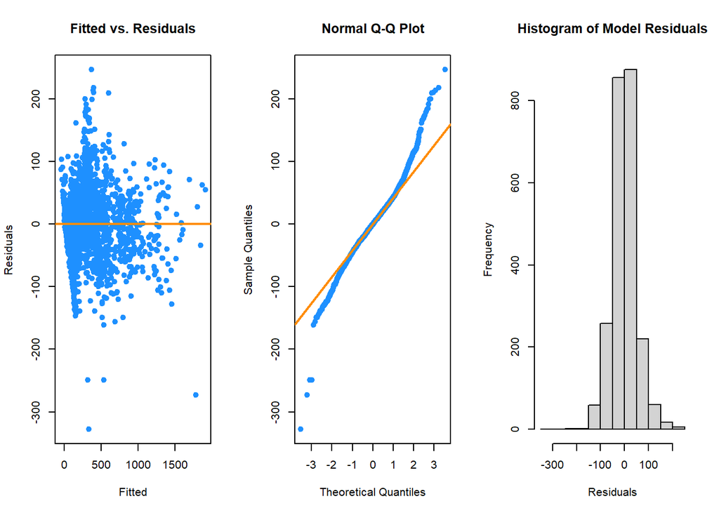

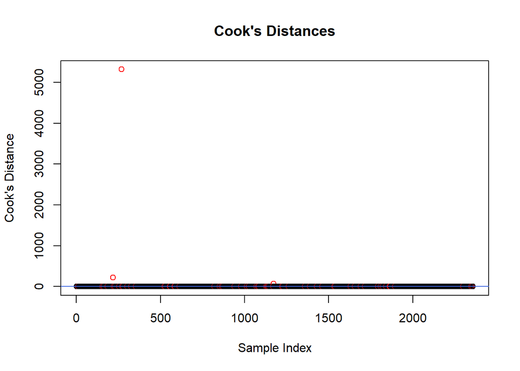

```
## [1] "LOOCV-RMSE:"      "1066.39243772091"
```

```r
baseline.poly.bc.cropyear_cont <- lm(
  paste(
    "bc_transform(Production, baseline.poly.bc.cropyear_cont_lambda) ~ ",
    paste(
      attr(terms(baseline.poly.form.cropyear_cont),
        which = "term.labels"
      ),
      collapse = " + "
    )
  ),
  data = crops.train.poly.no_infl
)
output_diagnostics(baseline.poly.bc.cropyear_cont, vif = 0)
```

Continuing on, we evaluate a model with other transformations of the predictors, including degree two, square roots, and logs of the continuous predictors (with the same improvements in mind).

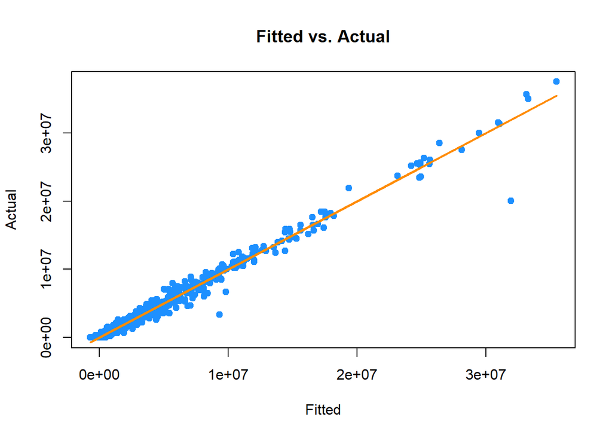

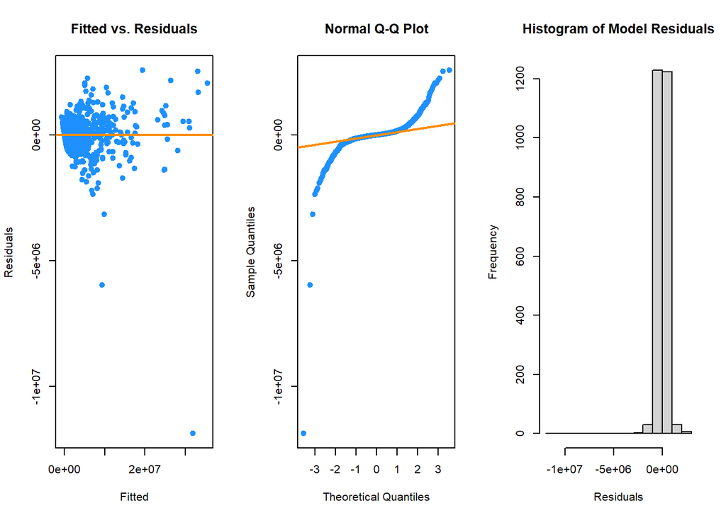

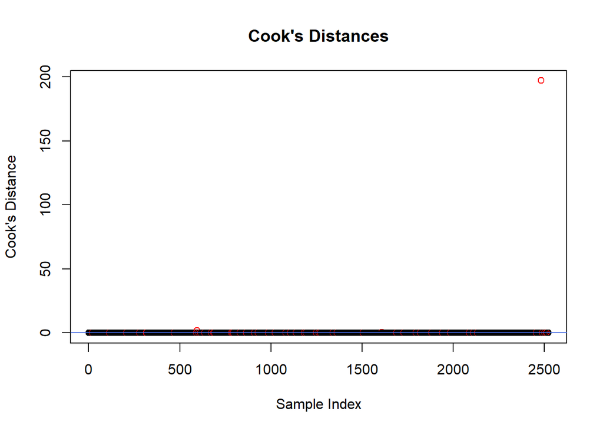

```
## [1] "LOOCV-RMSE:"      "2214248.87612306"
```

```r
multi.form.cropyear_cont <- as.formula(Production ~
  (poly(Area, degree = 2, raw = 1) +
    poly(Annual_Rainfall, degree = 2, raw = 1) +
    poly(Fertilizer, degree = 2, raw = 1) +
    poly(Pesticide, degree = 2, raw = 1) +
    poly(Crop_Year, degree = 2, raw = 1) +
    I(sqrt(Area)) +
    I(sqrt(Annual_Rainfall)) +
    I(sqrt(Fertilizer)) +
    I(sqrt(Pesticide)) +
    I(sqrt(Crop_Year)) +
    I(log(Area)) +
    I(log(Annual_Rainfall)) +
    I(log(Fertilizer)) +
    I(log(Pesticide)) +
    I(log(Crop_Year))) *
    (Crop + Season + Zone))
multi.full.cropyear_cont <- lm(multi.form.cropyear_cont, data = crops.train)
output_diagnostics(multi.full.cropyear_cont, vif = FALSE)
```

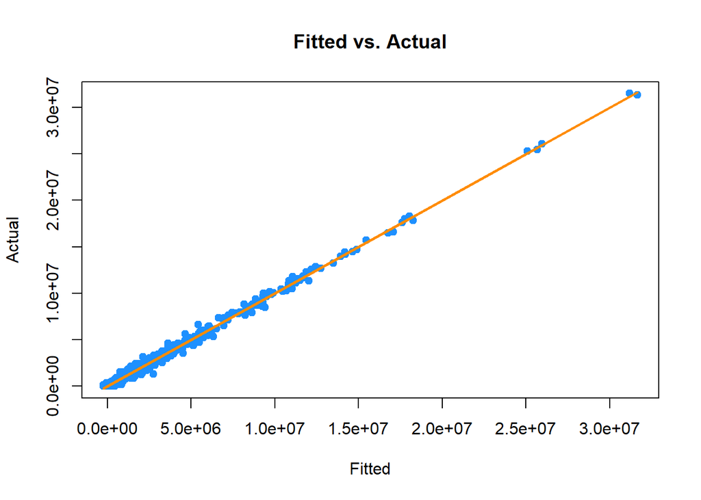

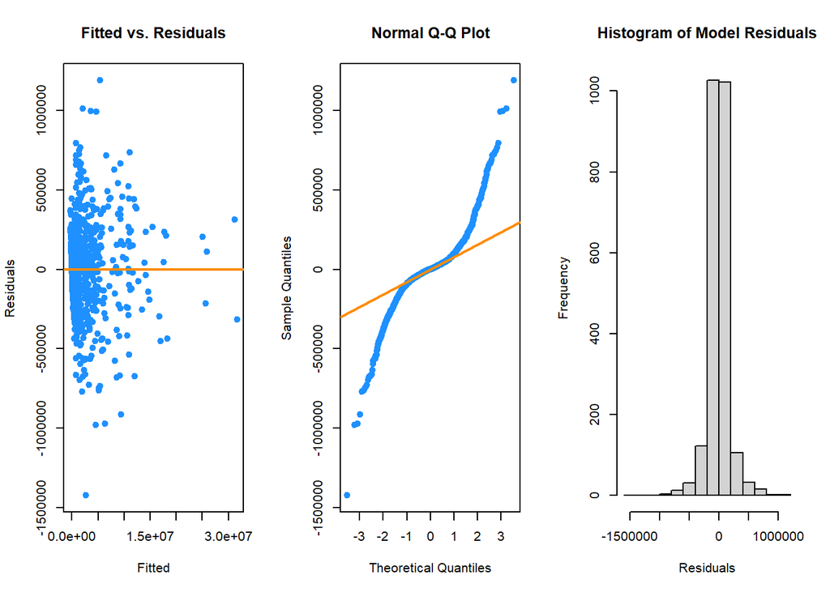

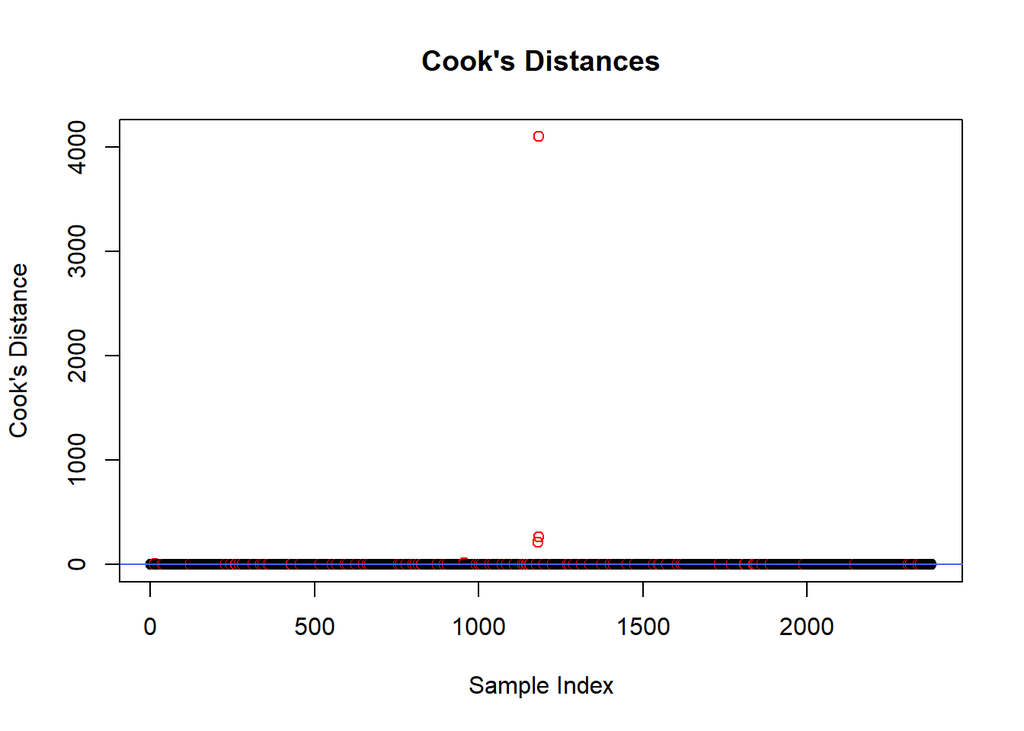

```
## [1] "LOOCV-RMSE:"      "4243834.94088267"
```

```r
crops.train.multi.no_infl <- crops.train[!idx_infl_pts(multi.full.cropyear_cont), ]

multi.full.cropyear_cont <- lm(multi.form.cropyear_cont, data = crops.train.multi.no_infl)
output_diagnostics(multi.full.cropyear_cont, vif = FALSE)
```

```r
bc <- boxcox(multi.full.cropyear_cont)
```

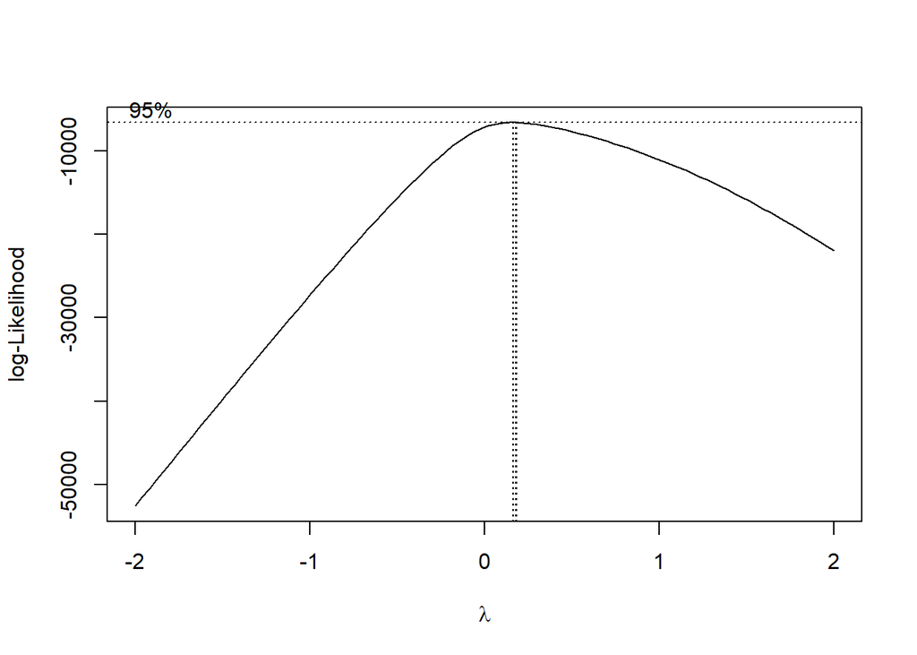

```r
(multi.full.bc.cropyear_cont_lambda <- bc$x[which.max(bc$y)])
```

```
## [1] 0.1818182
```